# BE 521: Homework 2 Questions

### Spring 2024

47 points

### Due: Feb 8th, 2024

Objective: Computational modeling of neurons. We gratefully acknowledge Dr. Vijay Balasubramanium (UPenn) for many of the questions in this homework.

```python
#Set up the notebook environment
import numpy as np
import matplotlib.pyplot as plt

!pip install git+https://github.com/ieeg-portal/ieegpy.git # Install ieegpy toolbox directly from github
from ieeg.auth import Session
```

```
  Cloning https://github.com/ieeg-portal/ieegpy.git to /tmp/pip-req-build-3zrfn516
  Running command git clone --filter=blob:none --quiet https://github.com/ieeg-portal/ieegpy.git /tmp/pip-req-build-3zrfn516
  Resolved https://github.com/ieeg-portal/ieegpy.git to commit 080bfa42a8503380ef164b5e7b116613f75073bb
  Preparing metadata (setup.py) ... done
     ━━━━━━━━━━━━━━━━━━━━━━━━━━━━━━━━━━━━━━━━ 98.0/98.0 kB 2.4 MB/s eta 0:00:00
```

## 1. Basic Membrane and Equilibrium Potentials (9 pts)

Before undertaking this section, you may find it useful to read pg. 153-161 of Dayan & Abbott's *Theoretical Neuroscience* (the relevant section of which, Ch. 5, is posted with this homework).

### 1

Recall that the potential difference $V_T$ when a mole of ions crosses a cell membrane is defined by the universal gas constant *R* = 8.31 J/mol ̇K, the temperature *T* (in Kelvin), and Faraday's constant *F* = 96,480 C/mol.

$$V_T = \frac{RT}{F}$$

Calculate $V_T$ at human physiological temperature (37°C). (1 pt)

```python
# My code here
# physiological temperature in Celius: 37°C
physio_T_Celius = 37
# physiological temperature in Kelvin: 310.15 K
physio_T_Kelvin = physio_T_Celius + 273.15
R = 8.31
F = 96480
V_T = (R * physio_T_Kelvin) / F
print("𝑉𝑇(V) at human physiological temperature (37°C): ", V_T, 'V')
print("𝑉𝑇(mV) at human physiological temperature (37°C): ", V_T * 1000, 'mV')
```

```
𝑉𝑇(V) at human physiological temperature (37°C):  0.026713790422885575 V
𝑉𝑇(mV) at human physiological temperature (37°C):  26.713790422885573 mV
```

**My Answer Here:**

𝑉𝑇(V) at human physiological temperature (37°C): **0.026713790422885575 V**

𝑉𝑇(mV) at human physiological temperature (37°C): **26.713790422885573 mV**

### 2

Use this value $V_T$ to calculate the Nerst equilibrium potentials (in mV) for the $K^+$, $Na^+$, and $Cl^-$ ions, given the following cytoplasm and extracellular concentrations in the squid giant axon\:

- $K^+$: (120, 4.5)
- $Na^+$: (15, 145)
- $Cl^-$: (12, 120)

The first number is the cytoplasmic concentration and the second number is the extracelluar concentration (in mM). (2pt)

```python
# My code here
### E(ion) = (RT/zF) * ln([ion]out / [ion]in)
Standard_T = 310
# One Positive Charge: z = 1
NEP_K = ((R * Standard_T) / (1 * F)) * np.log(4.5 / 120)
print("The Nerst equilibrium potentials (in mV) for the 𝐾+:", NEP_K * 1000, "mV")
# One Positive Charge: z = 1
NEP_Na = ((R * Standard_T) / (1 * F)) * np.log(145 / 15)
print("The Nerst equilibrium potentials (in mV) for the 𝑁𝑎+:", NEP_Na * 1000, "mV")
# One Negative Charge: z = -1
NEP_Cl = ((R * Standard_T) / (-1 * F)) * np.log(120 / 12)
print("The Nerst equilibrium potentials (in mV) for the 𝐶𝑙−:", NEP_Cl * 1000, "mV")
```

```
The Nerst equilibrium potentials (in mV) for the 𝐾+: -87.67002173243647 mV
The Nerst equilibrium potentials (in mV) for the 𝑁𝑎+: 60.575825775189045 mV
The Nerst equilibrium potentials (in mV) for the 𝐶𝑙−: -61.481026721206085 mV
```

**My Answer Here:**

The Nerst equilibrium potentials (in mV) for the **𝐾+**: **-87.67002173243647 mV**

The Nerst equilibrium potentials (in mV) for the **𝑁𝑎+**: **60.575825775189045 mV**

The Nerst equilibrium potentials (in mV) for the **𝐶𝑙−**: **-61.481026721206085 mV**

### 3

#### 3a

Use the Goldman equation,

$$ V_m = V_Tln(\frac{P_K \cdot [K^+]_{out} + P_{Na} \cdot [{Na}^+]_{out} + P_{Cl} \cdot [{Cl}^-]_{in}}{P_K \cdot [K^+]_{in} + P_{Na} \cdot [{Na}^+]_{in} + P_{Cl} \cdot [{Cl}^-]_{out}})$$

to calculate the resting membrane potential, $V_m$, assuming that the ratio of membrane permeabilities

$$P_K : P_{Na} : P_{Cl} = 1.0 : 0.045 : 0.45$$

Use the ion concentrations given in question 1.2. (2 pts)

```python
# My code here
P_K_out = 1.0 * 4.5
P_Na_out = 0.045 * 145
P_Cl_in  = 0.45 * 12
P_K_in = 1.0 * 120
P_Na_in = 0.045 * 15
P_Cl_out = 0.45 * 120
ln_Numerator = P_K_out + P_Na_out + P_Cl_in
ln_Denominator = P_K_in + P_Na_in + P_Cl_out
V_m = (V_T * 1000) * np.log(ln_Numerator / ln_Denominator)
print("The resting membrane potential: 𝑉𝑚 =", V_m, 'mV')
```

```
The resting membrane potential: 𝑉𝑚 = -63.154674069392186 mV
```

**My Answer Here:**

The resting membrane potential: 𝑉𝑚 = **-63.154674069392186 mV**

#### 3b

Calculate the membrane potential at the peak action potential, assuming a permeability ratio of 1.0 : 11 : 0.45, again using the ion concentrations given above in Question 1.2 (2 pts).

```python
# My code here
P_K_out_peak = 1.0 * 4.5
P_Na_out_peak = 11 * 145
P_Cl_in_peak  = 0.45 * 12
P_K_in_peak = 1.0 * 120
P_Na_in_peak = 11 * 15
P_Cl_out_peak = 0.45 * 120
ln_Numerator_peak = P_K_out_peak + P_Na_out_peak + P_Cl_in_peak
ln_Denominator_peak = P_K_in_peak + P_Na_in_peak + P_Cl_out_peak
V_m_peak = (V_T * 1000) * np.log(ln_Numerator_peak / ln_Denominator_peak)
print("The membrane potential at the peak action potential: 𝑉𝑚 = ", V_m_peak, 'mV')
```

```
The membrane potential at the peak action potential: 𝑉𝑚 =  41.5350453579882 mV
```

**My Answer Here:**

The membrane potential at the peak action potential: 𝑉𝑚 = **41.5350453579882 mV**

### 4

The amplitudes of the multi-unit signals in HW0 and local field potentials (LFPs) in HW1 had magnitudes on the order of 10 to 100 microvolts. The voltage at the peak of the action potential (determined using the Goldman equation above) has a magnitude on the order of 10 millivolts. Briefly explain why we see this difference in magnitude.

Hint 1: Voltage is the difference in electric potential between two points. What are the two points for our voltage measurement in the multi-unit and LFP signals? What are the two points for our voltage measurements of the action potential?

Hint 2: The resistance of the neuronal membrane is typically much higher than the resistance of the extracellular fluid. (2 pts)

**My Answer Here:**

Action potentials and multi-unit/LFP signals differ in magnitude due to the nature of voltage measurements. Voltage is recorded across the neuronal membrane in action potentials, whereas it is measured between the extracellular space and a reference electrode in multi-unit/LFP signals. Furthermore, the extracellular fluid has a far lower resistance than the neuronal membrane, which results in a more significant voltage shift during action potentials than the dispersed activity recorded by multi-unit/LFP signals.

[figure not shown]

## 2. Integrate and Fire Model (38 pts)

You may find it useful to read pg. 162-166 of Dayan and Abbott for this section. The general differential equation for the integrate and fire model is

$$\tau_m\frac{dV}{dt} = V_m - V(t) + R_m I_e(t)$$

where $\tau_m = 10\, \rm ms$ is the membrane time constant, describing how fast the current is leaking through the membrane, $V_m$ in this case is constant and represents the resting membrane potential (which you have already calculated in question 1.3.a), and $V(t)$ is the actual membrane potential as a function of time. $R_m = 10^7\, \Omega$ is the constant total membrane resistance, and $I_e(t)$ is the fluctuating incoming current. Here, we do not explicitly model the action potentials (that's Hodgkin-Huxley) but instead model the neuron's behavior leading up to and after the action potential.

Use a $\Delta t = 10\, \rm \mu s$ ($\Delta t$ is the discrete analog of the continuous $dt$). Remember, one strategy for modeling differential equations like this is to start with an initial condition (here, $V(0)=V_m$), then calculate the function change (here, $\Delta V$, the discrete analog to $dV$) and then add it to the function (here, $V(t)$) to get the next value at $t+\Delta t$. Once/if the membrane potential reaches a certain threshold ($V_{th} = -50\, \rm mV$), you will say that an action potential has occurred and reset the potential back to its resting value.

### 1

Model the membrane potential with a constant current injection (i.e., $I_e(t) = I_e = 2 {\rm nA}$). Plot your membrane potential as a function of time to show at least a handful of "firings." (8 pts)

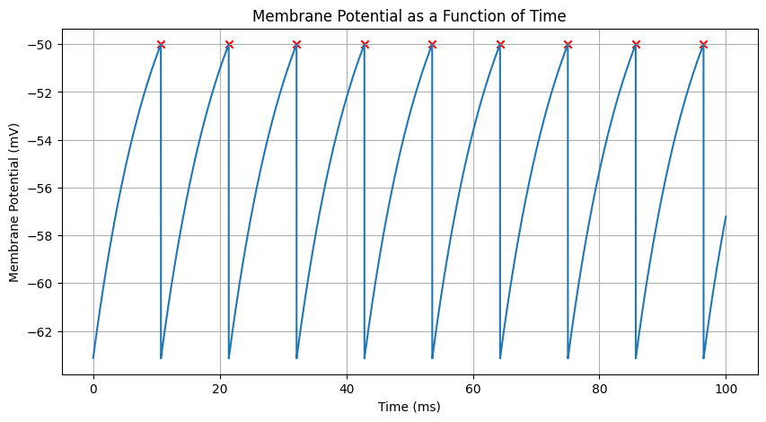

```python
# My code here

### Define given parameters

# constant membrane time constant 𝜏𝑚: 10 ms
tau_m = 10

# Resting membrane potential: V_m
#V_m_tmp = V_m

# Initial membrane potential = V_m, and then keep updating
Update_V = V_m

# Total membrane resistance (𝑅𝑚=10^7Ω)
Rm = 10**7

# constant current injection (i.e.𝐼𝑒(𝑡)=𝐼𝑒=2nA = 2 * 10^-6 mA)
I_e = 2 * 10**-6

# membrane potential reaches a certain threshold ( 𝑉𝑡ℎ=−50mV )
V_th = -50

# Δ𝑡=10𝜇s = 10^-2 ms
change_t = 10**-2

# random stimulation time (ms) for generating "firing"
simulation_time = 100

# Lists to store time slots and changeable membrane potentials
Time_Record_List = []
Membrane_Potential_List = []
Spike_Time_List = []
Spike_Potential_List = []

#print(np.arange(0, simulation_time, change_t))
# Simulation loop
for time in np.arange(0, simulation_time, change_t):
  derivative = (V_m - Update_V + Rm * I_e) / tau_m

  Update_V += derivative * change_t

  '''if Update_V == -63.134674069395736:
    #Update_V += derivative * change_t
    # Reset potential to start from initial potential
    print("error")'''
  # Check whether membrane potential reaches the certain threshold
  if Update_V >= V_th:
    # Reset potential to start from initial potential
    Spike_Time_List.append(time)
    Spike_Potential_List.append(Update_V)
    Update_V = V_m


  Time_Record_List.append(time)
  Membrane_Potential_List.append(Update_V)
#print(len(Spike_Time_List))

# Plotting
plt.figure(figsize = (10,5))
plt.plot(Time_Record_List, Membrane_Potential_List)
plt.title('Membrane Potential as a Function of Time')
plt.xlabel('Time (ms)')
plt.ylabel('Membrane Potential (mV)')
# The membrane potential reaches a certain threshold ( 𝑉𝑡ℎ=−50mV ): firing happens
plt.scatter(Spike_Time_List, Spike_Potential_List, marker = 'x', color = 'red')
plt.grid(True)
plt.show()
```

### 2

Produce a plot of firing rate (in Hz) versus injection current, over the range of 1-4 nA. (4 pts)

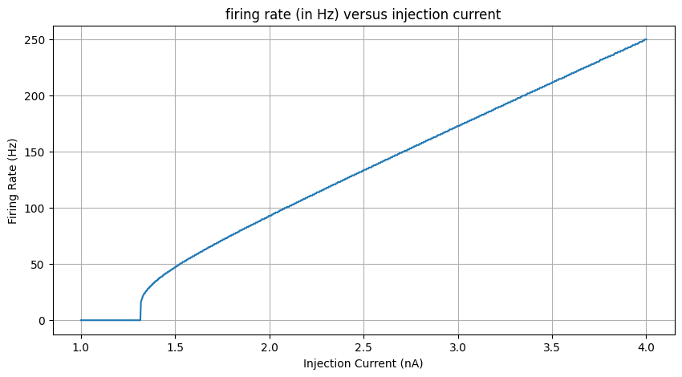

```python
# My code here

### Record number of spikes happen in each cycle of injection current
def Get_Spike_Length(I_e):
  tau_m = 10
  V_m = -63.154674069392186
  Update_V = V_m
  Rm = 10**7
  V_th = -50
  change_t = 10**-2
  simulation_time = 1000

  Spike_Length = 0

  Time_Record_List = []
  Membrane_Potential_List = []
  Spike_Time_List = []
  Spike_Potential_List = []

  for time_new in np.arange(0, simulation_time, change_t):
    derivative = (V_m - Update_V + Rm * I_e) / tau_m
    Update_V += derivative * change_t

    # Check whether membrane potential reaches the certain threshold
    if Update_V >= V_th:
      Spike_Length += 1
      Update_V = V_m

  return Spike_Length

Injection_Current = np.linspace(10**-6, 4 * 10**-6, num=1000)

firing_rate_list = []
simulation_time_ms = 1000

for Update_I_e in Injection_Current:

  Update_Spike_Length = Get_Spike_Length(Update_I_e)

  ### 1 Hz = 1 cycle/s, 1s = 1000ms -> 1 cycle/ms = 1000 cycle/s = 1000 Hz
  firing_rate = (Update_Spike_Length / simulation_time_ms) * 1000
  firing_rate_list.append(firing_rate)

plt.figure(figsize = (10,5))
plt.title('firing rate (in Hz) versus injection current')
plt.xlabel('Injection Current (nA)')
plt.ylabel('Firing Rate (Hz)')
plt.plot(Injection_Current * 10**6, firing_rate_list)
plt.grid(True)
plt.show()
```

### 3

`I521_A0002_D001` contains a dynamic current injection in nA. Plot the membrane potential of your neuron in response to this variable injection current. Use [`plt.subplots()`](https://matplotlib.org/stable/api/_as_gen/matplotlib.pyplot.subplots.html) to place the plot of the membrane potential above the injection current so that they both have the same time axis. (Hint: the sampling frequency of the current injection data is different from the sampling frequency ($\frac{1}{\Delta t}$) that we used above.) (4 pts)

```python
# Your code here
# get the specified dataset from IEEG
# open the binary file and use its content to create a session frmo IEEG
with open('/content/Yua_ieeglogin.bin', 'r') as f:
  session = Session('Yuanchz1118', f.read())

dataset = session.open_dataset('I521_A0002_D001')
label = dataset.get_channel_labels()
print(label)
index = dataset.get_channel_indices(label)
print(index)
timeseries_Ie = dataset.get_time_series_details(label[0])
print(timeseries_Ie)
#timeseries_stim = dataset_new.get_time_series_details(label_new[1])

sample_freq = timeseries_Ie.sample_rate
print(sample_freq)

start_time = timeseries_Ie.start_time
end_time = timeseries_Ie.end_time
duration = timeseries_Ie.duration
injection_current = dataset.get_data(start_time, end_time - 1, index)
print(injection_current)
time_range = np.arange(start_time, end_time, duration / len(injection_current))
print(time_range)
```

```
['Ie']
[0]
None(Ie) spans 499999.0 usec, range [0-2574872] in 500000 samples. Starts @1 uUTC, ends @500000 uUTC with sample rate 1000000.0 Hz and voltage conv factor 1e-06
1000000.0
[[1.120725]
 [1.120796]
 [1.120867]
 ...
 [1.120754]
 [1.120721]
 [1.120688]]
[1.00000e+00 2.00000e+00 3.00000e+00 ... 4.99997e+05 4.99998e+05
 4.99999e+05]
```

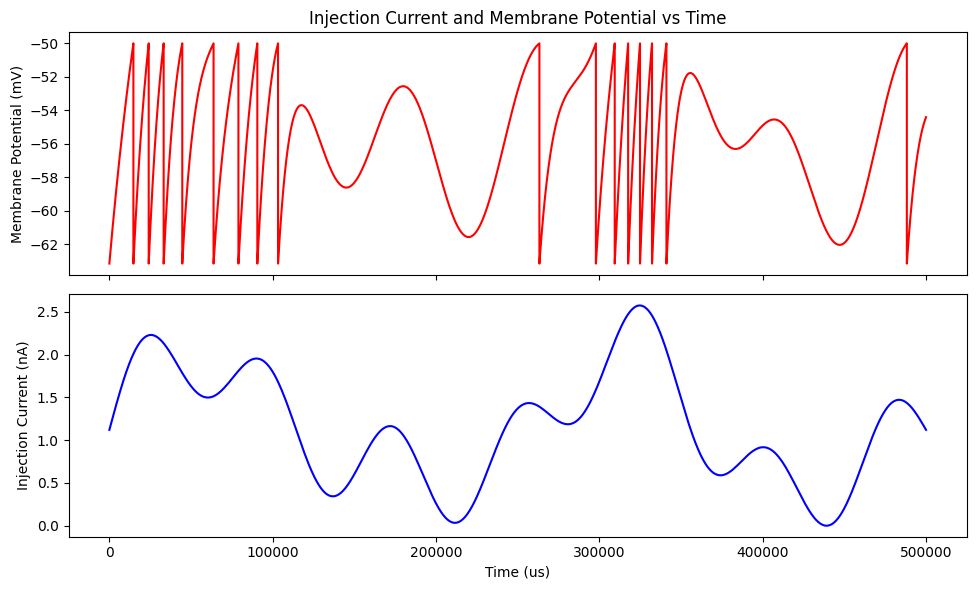

```python
#def calculate_membrane_potential(injection_current, V_m=-63.154674069392186):
tau_m = 10
Rm = 10**7
V_th = -50
change_t_tmp = 1 / sample_freq * 1000  # Change this to match the sampling interval of your membrane potential data
membrane_potential_tmp = []
Update_V = V_m

for current in range(0, len(injection_current)):
  #for time in np.arange(0, duration, change_t):
  #print(current)
  #Update_V = V_m
  derivative = (V_m - Update_V + Rm * injection_current[current, 0] * 10**-6) / tau_m
  Update_V += derivative * change_t_tmp

  if Update_V >= V_th:
    # Reset potential to start from initial potential
    Update_V = V_m

  membrane_potential_tmp.append(Update_V)

  #return membrane_potential

# Calculate membrane potential response
# membrane_potential = calculate_membrane_potential(injection_current * 10**-6)
# print(membrane_potential_tmp)
# Plotting
fig, (plt1, plt2) = plt.subplots(2, 1, figsize=(10, 6), sharex=True)

# Plot membrane potential
plt1.set_title('Injection Current and Membrane Potential vs Time')
plt1.plot(time_range, membrane_potential_tmp, color='red')
plt1.set_ylabel('Membrane Potential (mV)')
#ax1.set_xlabel('Time (us)')

# Plot injection current
plt2.plot(time_range, injection_current, color='blue')
plt2.set_ylabel('Injection Current (nA)')
plt2.set_xlabel('Time (us)')
#ax2.set_title('Injection Current and Membrane Potential vs Time')

plt.tight_layout()
plt.show()
```

### 4

Real neurons have a refractory period after an action potential that prevents them from firing again right away. We can include this behavior in the model by adding a spike-rate adaptation conductance term, $g_{sra}(t)$ (modeled as a potassium conductance), to the model $$\tau_m\frac{dV}{dt} = V_m - V(t) - r_m g_{sra}(t)(V(t)-V_K)+ R_m I_e(t)$$ where $$ \tau_{sra}\frac{dg_{sra}(t)}{dt} = -g_{sra}(t).$$ Every time an action potential occurs, we increase $g_{sra}$ by a certain constant amount, $g_{sra} = g_{sra} + \Delta g_{sra}$. Use $r_m \Delta g_{sra} = 0.06$. Use a conductance time constant of $\tau_{sra} = 100\, \rm ms$, a potassium equilibrium potential of $V_K = -70\, \rm mV$, and $g_{sra}(0) = 0$. (Hint: How can you use the $r_m \Delta g_{sra}$ value to update voltage and conductance separately in your simulation?)

#### 4a

Implement this addition to the model (using the same other parameters as in question 2.1) and plot the membrane potential over 200 ms. (8 pts)

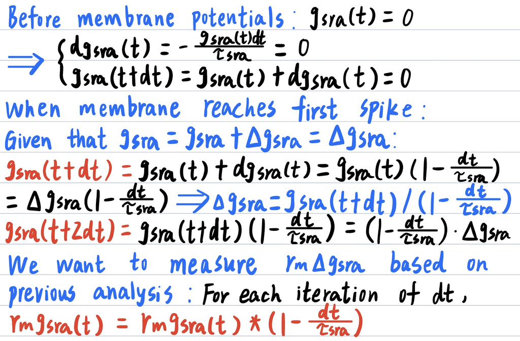

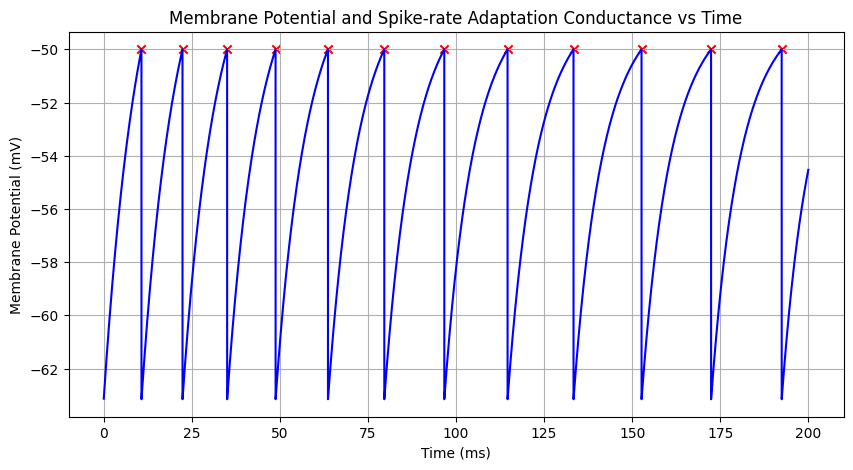

```python
# My code here
change_t1 = 0.01  # Change this to match the sampling interval of your membrane potential data
simulation_time_new = 200
tau_sra=100
delta_g_sra=0.06
r_m_g_sra = 0
V_K=-70
Update_V_New = V_m

Time_Record_List1 = []
membrane_potential = []
r_m_g_sra_list1 = []
Spike_Time_List1 = []
Spike_Potential_List1 = []

for time_new2 in np.arange(0, simulation_time_new, change_t1):

  r_m_g_sra *= (1 - change_t1 / tau_sra)  # Updated calculation
  derivative_new = (V_m - Update_V_New - r_m_g_sra * (Update_V_New - V_K) + Rm * I_e) / tau_m
  Update_V_New += derivative_new * change_t1

  # Check for spiking
  if Update_V_New >= V_th:
    Spike_Time_List1.append(time_new2)
    Spike_Potential_List1.append(Update_V_New)

    r_m_g_sra += delta_g_sra
    r_m_g_sra_list1.append(r_m_g_sra)
    Update_V_New = V_m

  Time_Record_List1.append(time_new2)
  membrane_potential.append(Update_V_New)

plt.figure(figsize = (10,5))
plt.xlabel('Time (ms)')
plt.ylabel('Membrane Potential (mV)')
plt.plot(Time_Record_List1, membrane_potential, color='blue')
plt.scatter(Spike_Time_List1, Spike_Potential_List1, marker = 'x', color = 'red')
plt.title('Membrane Potential and Spike-rate Adaptation Conductance vs Time')
plt.grid(True)
plt.show()
```

#### 4b

Plot the inter-spike interval (the time between the spikes) of all the spikes that occur in 500 ms. (2 pts)

```
The time between the spikes of all the spikes that occur in 500 ms:
 [11.65 12.67 13.75 14.87 15.99 17.03 17.96 18.72 19.31 19.74 20.04 20.24
 20.38 20.46 20.52 20.56 20.58 20.59 20.6  20.61 20.61 20.61 20.62 20.62
 20.62]
```

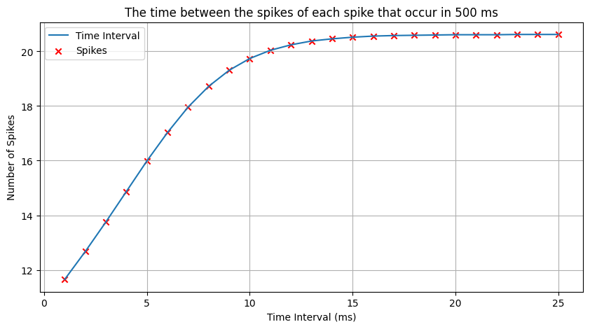

```python
# My code here
Spike_Time_List2 = []
Spike_Potential_List2 = []
Time_Record_List2 = []
membrane_potential2 = []
r_m_g_sra_list2 = []
Spike_Interval_List = []
change_t2 = 0.01
r_m_g_sra2 = 0
Update_V_New2 = V_m
time_new3 = 0
simulation_time_new2 = 500
interval = 0
#count = 0
for time_new3 in np.arange(0, simulation_time_new2, change_t2):

  r_m_g_sra2 *= (1 - change_t2 / tau_sra)  # Updated calculation
  derivative_new2 = (V_m - Update_V_New2 - r_m_g_sra2 * (Update_V_New2 - V_K) + Rm * I_e) / tau_m
  Update_V_New2 += derivative_new2 * change_t2

  # Check for spiking

  if Update_V_New2 >= V_th:

    Spike_Time_List2.append(time_new3)
    Spike_Potential_List2.append(Update_V_New2)
    #Spike_Count_List.append(tmp)
    #tmp = tmp + 1
    #print(Spike_Time_List2)

    r_m_g_sra2 += delta_g_sra
    r_m_g_sra_list2.append(r_m_g_sra2)
    Update_V_New2 = V_m

  Time_Record_List2.append(time_new3)
  membrane_potential2.append(Update_V_New2)

Spike_Interval = np.diff(Spike_Time_List2)
print("The time between the spikes of all the spikes that occur in 500 ms:\n", Spike_Interval, '\n')

### Plot of entire time intervals in 500ms
'''Spike_Count = np.arange(1,len(Spike_Time_List2)+1)
plt.xlabel('Time (ms)')
plt.ylabel('Number of Spikes')
plt.plot(Spike_Time_List2, Spike_Count)
plt.scatter(Spike_Time_List2, Spike_Count, marker = 'x', color = 'red')
plt.show()'''

### Plot of each time interval in 500ms
Spike_Count = np.arange(1,len(Spike_Time_List2))
plt.figure(figsize = (10,5))
plt.title("The time between the spikes of each spike that occur in 500 ms")
plt.xlabel('Time Interval (ms)')
plt.ylabel('Number of Spikes')
plt.plot(Spike_Count, Spike_Interval, label = 'Time Interval')
plt.scatter(Spike_Count, Spike_Interval, marker = 'x', color = 'red', label = 'Spikes')
plt.legend(loc = 'upper left')
plt.grid(True)
plt.show()
```

#### 4c

Explain how the spike-rate adaptation term we introduced above might be contributing to the behavior you observe in 2.4.b. (2 pts)

**My Answer Here:**

From the plot "The time between the spikes of each spike that occur in 500 ms" in 2.4.b., we can obviously observe that spike-rate adaptation increases the interval of spikes to enable spikes to appear less frequently.

### 5

Pursue an extension of this basic integrate and fire model. A few ideas are: implement the Integrate-and-Fire-or-Burst Model of Smith et al. 2000 (included); implement the Hodgkin-Huxley model (see Dayan and Abbot, pg. 173); provide some sort of interesting model of a population of neurons; or perhaps model what an electrode sampling at 200 Hz would record from the signal you produce in question 2.3. Feel free to be creative. We reserve the right to give extra credit to particularly interesting extensions and will in general be more generous with points for more difficult extensions (like the first two ideas), though it is possible to get full credit for any well-done extension.

#### 5a

Briefly describe what your extension is and how you will execute it in code. (6 pts)

**My Answer Here:**

**[1]** The extension entails simulating the dynamics of ion channels and action potentials using the Hodgkin-Huxley model, a biophysically precise neural model. I need to express the dynamics of sodium, potassium, and leak channels in my code to satisfy various equations based on the Hodgkin-Huxley equations must be defined. The membrane potential dynamics over time will be simulated by numerically integrating these equations. I will also include characteristics like membrane capacitance, ion channel conductances, and starting circumstances to represent neuronal activity precisely. The resultant simulation will enable the investigation of diverse firing patterns and neuronal excitability states, offering insights into the production and propagation of action potentials.

**Reference:**

**[1]** E. M. Izhikevich, "Neural excitability, spiking and bursting," International Journal of Bifurcation and Chaos, vol. 10, no. 6, pp. 1171-1266, Jun. 2000.

https://boulderschool.yale.edu/sites/default/files/files/DayanAbbott.pdf

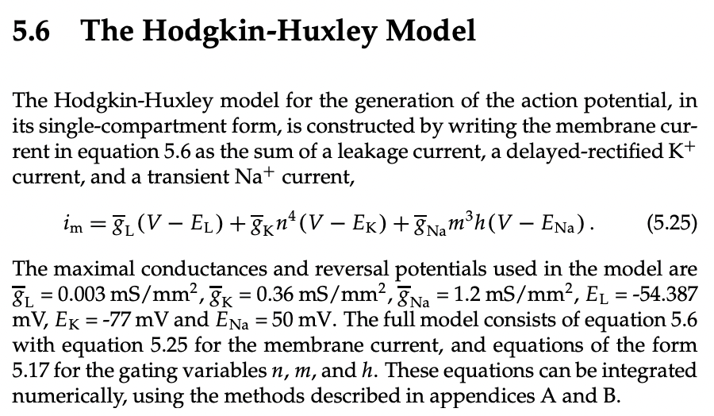

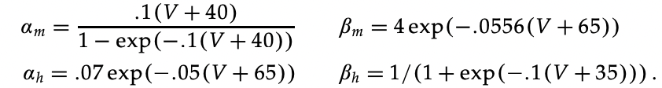

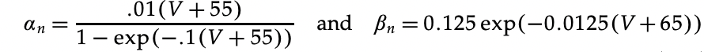

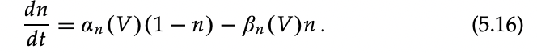

#### 5b

Provide an interesting figure along with an explanation illustrating the extension. (4 pts)

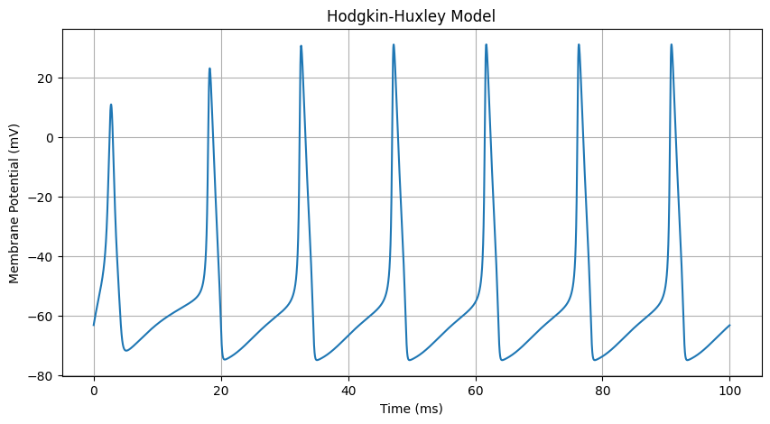

```python
# My code here

# Define Hodgkin-Huxley model parameters

# Max sodium conductance (mS/cm^2)
g_Na = 120

# Max potassium conductance (mS/cm^2)
g_K = 36

# Leak conductance (mS/cm^2) : = 0.003 mS/mm^2 = 0.3 mS/cm^2
g_L = 0.3

# Sodium equilibrium potential (mV)
E_Na = 50

# Potassium equilibrium potential (mV)
E_K = -77

# Leak equilibrium potential (mV)
E_L = -54.387

# Define the differential equations for the gating variables (m, h, n)
# Rate at which the activation gate (m) of the sodium ion channels opens
def alpha_m(V): return 0.1*(V+40)/(1 - np.exp(-0.1*(V+40)))
def alpha_h(V): return 0.07*np.exp(-0.05*(V+65))
def alpha_n(V): return 0.01*(V+55)/(1 - np.exp(-(V+55)/10))

def beta_m(V): return 4.0*np.exp(-(V+65)/18)
def beta_h(V): return 1/(1 + np.exp(-(V+35)/10))
def beta_n(V): return 0.125*np.exp(-(V+65)/80)

# Define the Hodgkin-Huxley model equations with gating variables n, m, and h
def dV_dt(V, m, h, n, I):
    #dV = (I - g_Na * m**3 * h * (V - E_Na) - g_K * n**4 * (V - E_K) - g_L * (V - E_L)) / C_m
    dV = I - g_L * (V - E_L) - g_K * n**4 * (V - E_K) - g_Na * m**3 * h * (V - E_Na)
    return dV

# gating variable m
def dm_dt(V, m):
    return alpha_m(V)*(1 - m) - beta_m(V)*m

# gating variable h
def dh_dt(V, h):
    return alpha_h(V)*(1 - h) - beta_h(V)*h

# gating variable n
def dn_dt(V, n):
    return alpha_n(V)*(1 - n) - beta_n(V)*n

# Simulation parameters
dt = 0.01   # Time step (ms)
T = 100      # Total simulation time (ms)
num_steps = int(T / dt)

# Initialize variables
V = V_m     # Initial membrane potential (mV)
m, h, n = 0, 0, 0  # Initial gating variables
I = 10      # Applied current (uA/cm^2)

# Lists to store data
time_distribution = np.arange(0, T, dt)
membrane_potential_model = np.zeros(num_steps)

step = 0
# Simulation loop
#for step in range(num_steps):
while step < num_steps:
    membrane_potential_model[step] = V
    m += dt * dm_dt(V, m)
    h += dt * dh_dt(V, h)
    n += dt * dn_dt(V, n)
    V += dt * dV_dt(V, m, h, n, I)

    step = step + 1

# Plotting
plt.figure(figsize = (10,5))
plt.plot(time_distribution, membrane_potential_model)
plt.xlabel('Time (ms)')
plt.ylabel('Membrane Potential (mV)')
plt.title('Hodgkin-Huxley Model')
plt.grid(True)
plt.show()
```

**My Answer Here:**

Compared to previous plots with particular spikes as membrane potential reaches threshold V_th = -50mV, the Hodgkin-Huxley enables systems to enjoy the adjustable spikes, which are closer to accurate research results.

For a more theoretical explanation, the Hodgkin-Huxley model is akin to delving deeply into the specifics of how such spikes genuinely transpire. It's similar to seeing through small gates that allow ions like sodium and potassium to enter and exit neurons to observe all the activity occurring inside. The model may simulate the firing patterns of actual neurons by examining how these channels open and shut in response to voltage variations. It's similar to witnessing the entire ion dance that precedes a spike, from the first surge of sodium entering the system to the subsequent decrease of potassium leaving the body!